# Trabajo Personal

Ines Garcia

24/1/2022

```r
library(nycflights13)
library(tidyverse)
vuelos <- nycflights13::flights
```

#### 1.Encuentra todos los vuelos que llegaron más de una hora tarde de lo previsto.

```r
a <-filter(vuelos, arr_delay >60)
dim(a)
```

```
## [1] 27789    19
```

Los vuelos que llegaron más de una tarde de lo previsto fueron 27789

#### 2.Encuentra todos los vuelos que volaron hacia San Francisco (aeropuertos SFO y OAK)

```r
b <- filter(vuelos, dest == "SFO" | dest== "OAK")
dim(b)
```

```
## [1] 13643    19
```

Los vuelos que volaron hacia los aeropuertos de San Francisco fueron 13643.

#### 3. Encuentra todos los vuelos operados por United American (UA) o por American Airlines (AA)

```r
c <-filter(vuelos, carrier == "UA" | carrier == "AA")
dim(c)
```

```
## [1] 91394    19
```

Los vuelos operados por United American o por American Airlines fueron 91394.

#### 4.Encuentra todos los vuelos que salieron los meses de primavera (Abril, Mayo y Junio)

```r
d <- filter(vuelos, month == 4 | month == 5 |month == 6)
dim(d)
```

```
## [1] 85369    19
```

Los vuelos que salieron los meses de Abril, Mayo y Junio fueron 85369.

#### 5. Encuentra todos los vuelos que llegaron más de una hora tarde pero salieron con menos de una hora de retraso.

```r
e <-filter(vuelos, arr_delay > 60 & dep_delay <60)
dim(e)
```

```
## [1] 4956   19
```

Los vuelos que salieron más de una hora tarde pero salieron con menos de una hora de retraso fueron 4956.

#### 6.Encuentra todos los vuelos que salieron con más de una hora de retraso pero consiguieron llegar con menos de 30 minutos de retraso (el avión aceleró en el aire)

```r
f <-filter(vuelos, arr_delay <30 & dep_delay >60)
dim(f)
```

```
## [1] 181  19
```

Los vuelos que salieron con más de una hora de retraso pero consiguieron llegar con menos de 30 min de retraso fueron 181.

#### 7. Encuentra todos los vuelos que salen entre medianoche y las 7 de la mañana (vuelos nocturnos).

```r
g <-filter(vuelos, dep_time <=700)
dim(g)
```

```
## [1] 31958    19
```

Los vuelos que salieron entre medianoche y las 7 de la mañana fueron 31958.

#### 8. ¿Cuántos vuelos tienen un valor desconocido de dep_time?

```r
h <- which(is.na(vuelos$dep_time))
length(h)
```

```
## [1] 8255
```

El número de vuelos que tienen un valor desconocido es de 8255.

#### 9. ¿Qué variables del dataset contienen valores desconocidos?

```r
apply(X = is.na(vuelos), MARGIN = 2, FUN = sum)
```

```
##           year          month            day       dep_time sched_dep_time
##              0              0              0           8255              0
##      dep_delay       arr_time sched_arr_time      arr_delay        carrier
##           8255           8713              0           9430              0
##         flight        tailnum         origin           dest       air_time
##              0           2512              0              0           9430
##       distance           hour         minute      time_hour
##              0              0              0              0
```

Las variables que tienen valores NA son: tailnum, dep_time, de_delay, arr_time, arr_delay y air_time.

#### 10. Ordena los vuelos de flights para encontrar los vuelos más retrasados en la salida. ¿Qué vuelos fueron los que salieron los primeros antes de lo previsto?

```r
arrange(vuelos, desc(dep_delay))
```

```
## # A tibble: 336,776 x 19
##     year month   day dep_time sched_dep_time dep_delay arr_time sched_arr_time
##    <int> <int> <int>    <int>          <int>     <dbl>    <int>          <int>
##  1  2013     1     9      641            900      1301     1242           1530
##  2  2013     6    15     1432           1935      1137     1607           2120
##  3  2013     1    10     1121           1635      1126     1239           1810
##  4  2013     9    20     1139           1845      1014     1457           2210
##  5  2013     7    22      845           1600      1005     1044           1815
##  6  2013     4    10     1100           1900       960     1342           2211
##  7  2013     3    17     2321            810       911      135           1020
##  8  2013     6    27      959           1900       899     1236           2226
##  9  2013     7    22     2257            759       898      121           1026
## 10  2013    12     5      756           1700       896     1058           2020
## # ... with 336,766 more rows, and 11 more variables: arr_delay <dbl>,
## #   carrier <chr>, flight <int>, tailnum <chr>, origin <chr>, dest <chr>,
## #   air_time <dbl>, distance <dbl>, hour <dbl>, minute <dbl>, time_hour <dttm>
```

```r
arrange(vuelos, dep_delay)
```

```
## # A tibble: 336,776 x 19
##     year month   day dep_time sched_dep_time dep_delay arr_time sched_arr_time
##    <int> <int> <int>    <int>          <int>     <dbl>    <int>          <int>
##  1  2013    12     7     2040           2123       -43       40           2352
##  2  2013     2     3     2022           2055       -33     2240           2338
##  3  2013    11    10     1408           1440       -32     1549           1559
##  4  2013     1    11     1900           1930       -30     2233           2243
##  5  2013     1    29     1703           1730       -27     1947           1957
##  6  2013     8     9      729            755       -26     1002            955
##  7  2013    10    23     1907           1932       -25     2143           2143
##  8  2013     3    30     2030           2055       -25     2213           2250
##  9  2013     3     2     1431           1455       -24     1601           1631
## 10  2013     5     5      934            958       -24     1225           1309
## # ... with 336,766 more rows, and 11 more variables: arr_delay <dbl>,
## #   carrier <chr>, flight <int>, tailnum <chr>, origin <chr>, dest <chr>,
## #   air_time <dbl>, distance <dbl>, hour <dbl>, minute <dbl>, time_hour <dttm>
```

El vuelo que más temprano salío antes de lo previsto es el que tiene un tailnum de N592JB y salío 43 minutos antes. El segundo vuelo que más temprano salío es el que tiene un tailnum de N612DL y salío 33 minutos antes.

#### 11. Ordena los vuelos de flights para encontrar los vuelos más rápidos. Usa el concepto de rapidez que consideres.

```r
vuelos$velocidad <- vuelos$distance/vuelos$air_time
arrange(vuelos, desc(velocidad))
```

```
## # A tibble: 336,776 x 20
##     year month   day dep_time sched_dep_time dep_delay arr_time sched_arr_time
##    <int> <int> <int>    <int>          <int>     <dbl>    <int>          <int>
##  1  2013     5    25     1709           1700         9     1923           1937
##  2  2013     7     2     1558           1513        45     1745           1719
##  3  2013     5    13     2040           2025        15     2225           2226
##  4  2013     3    23     1914           1910         4     2045           2043
##  5  2013     1    12     1559           1600        -1     1849           1917
##  6  2013    11    17      650            655        -5     1059           1150
##  7  2013     2    21     2355           2358        -3      412            438
##  8  2013    11    17      759            800        -1     1212           1255
##  9  2013    11    16     2003           1925        38       17             36
## 10  2013    11    16     2349           2359       -10      402            440
## # ... with 336,766 more rows, and 12 more variables: arr_delay <dbl>,
## #   carrier <chr>, flight <int>, tailnum <chr>, origin <chr>, dest <chr>,
## #   air_time <dbl>, distance <dbl>, hour <dbl>, minute <dbl>, time_hour <dttm>,
## #   velocidad <dbl>
```

#### 12. ¿Qué vuelos tienen los trayectos más largos?

```r
arrange(vuelos, desc(distance))
```

```
## # A tibble: 336,776 x 20
##     year month   day dep_time sched_dep_time dep_delay arr_time sched_arr_time
##    <int> <int> <int>    <int>          <int>     <dbl>    <int>          <int>
##  1  2013     1     1      857            900        -3     1516           1530
##  2  2013     1     2      909            900         9     1525           1530
##  3  2013     1     3      914            900        14     1504           1530
##  4  2013     1     4      900            900         0     1516           1530
##  5  2013     1     5      858            900        -2     1519           1530
##  6  2013     1     6     1019            900        79     1558           1530
##  7  2013     1     7     1042            900       102     1620           1530
##  8  2013     1     8      901            900         1     1504           1530
##  9  2013     1     9      641            900      1301     1242           1530
## 10  2013     1    10      859            900        -1     1449           1530
## # ... with 336,766 more rows, and 12 more variables: arr_delay <dbl>,
## #   carrier <chr>, flight <int>, tailnum <chr>, origin <chr>, dest <chr>,
## #   air_time <dbl>, distance <dbl>, hour <dbl>, minute <dbl>, time_hour <dttm>,
## #   velocidad <dbl>
```

El trayecto más largo es el que sale del aeropuerto JFK y aterriza en el aeropuerto HNL, cuya distancia total es de 4983 millas.

#### 13. ¿Qué vuelos tienen los trayectos más cortos?

```r
arrange(vuelos, distance)
```

```
## # A tibble: 336,776 x 20
##     year month   day dep_time sched_dep_time dep_delay arr_time sched_arr_time
##    <int> <int> <int>    <int>          <int>     <dbl>    <int>          <int>
##  1  2013     7    27       NA            106        NA       NA            245
##  2  2013     1     3     2127           2129        -2     2222           2224
##  3  2013     1     4     1240           1200        40     1333           1306
##  4  2013     1     4     1829           1615       134     1937           1721
##  5  2013     1     4     2128           2129        -1     2218           2224
##  6  2013     1     5     1155           1200        -5     1241           1306
##  7  2013     1     6     2125           2129        -4     2224           2224
##  8  2013     1     7     2124           2129        -5     2212           2224
##  9  2013     1     8     2127           2130        -3     2304           2225
## 10  2013     1     9     2126           2129        -3     2217           2224
## # ... with 336,766 more rows, and 12 more variables: arr_delay <dbl>,
## #   carrier <chr>, flight <int>, tailnum <chr>, origin <chr>, dest <chr>,
## #   air_time <dbl>, distance <dbl>, hour <dbl>, minute <dbl>, time_hour <dttm>,
## #   velocidad <dbl>
```

El trayecto más corto es de 80 millas, sale del aeropuerto EWR y aterriza en PHL, el primer vuelo cuyo trayecto es de 17 millas corresponde al de un vuelo cancelado, es por este motivo que no lo tengo en cuenta como trayecto más corto.

#### 14. El dataset de vuelos tiene dos variables, dep_time y sched_dep_time muy útiles pero difíciles de usar por cómo vienen dadas al no ser variables continuas. Fíjate que cuando pone 559, se refiere a que el vuelo salió a las 5:59… Convierte este dato en otro más útil que represente el número de minutos que pasan desde media noche.

```r
vuelos_min <-mutate(vuelos, salida_programada_min = (sched_dep_time %/% 100 * 60 + sched_dep_time %% 100) %% 1440, salida_min = (dep_time %/% 100 * 60 + dep_time %% 100) %% 1440)
```

#### 15. Compara los valores de dep_time, sched_dep_time y dep_delay. ¿Cómo deberían relacionarse estos tres números? Compruébalo y haz las correcciones numéricas que necesitas.

```r
vuelos_min$comprobacion1 <- vuelos_min$sched_dep_time + vuelos_min$dep_delay
vuelos_min$comprobacion2 <- vuelos_min$salida_programada_min + vuelos_min$dep_delay
```

#### 16. Investiga si existe algún patrón del número de vuelos que se cancelan cada día.

```r
vueloscancelados <-  vuelos %>%
  mutate(cancelado = (is.na(arr_delay) | is.na(arr_delay))) %>%
  group_by(year, month, day) %>%
  summarise(num_cancelado = sum(cancelado), num_vuelo = n(),)
```

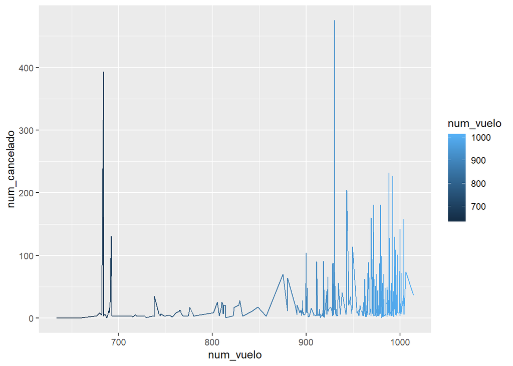

```r
library(ggplot2)
ggplot(vueloscancelados) +
  geom_line(mapping = aes(x = num_vuelo, y = num_cancelado, col=num_vuelo, ))
```

#### 17. Investiga si la proporción de vuelos cancelados está relacionada con el retraso promedio por día en los vuelos.

```r
proporcion_retraso <- vuelos %>%
  mutate(cancelados = (is.na(tailnum))) %>%
  group_by(year, month, day) %>%
  summarise(proporcion_cancelados = mean(cancelados),media_dep_delay = mean(dep_delay, na.rm = TRUE),med_arr_delay = mean(arr_delay, na.rm = TRUE)) %>% ungroup()
```

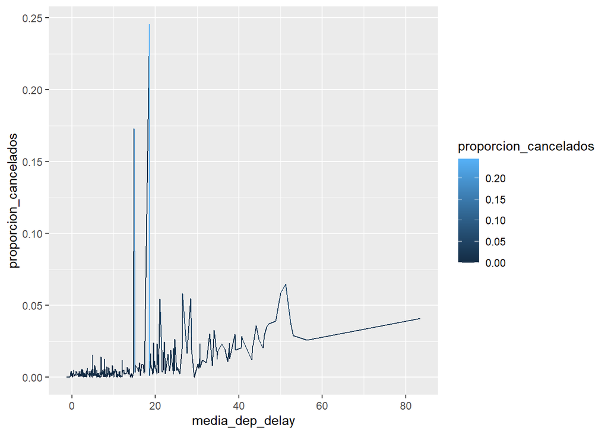

```r
ggplot(proporcion_retraso) +
  geom_line(aes(x = media_dep_delay, y = proporcion_cancelados, col=proporcion_cancelados))
```

Observando la gráfica obtenida no podemos llegar a una conclusión clara de que exista o no una relación entre ambas variables.

#### 18. Investiga si la proporción de vuelos cancelados está relacionada con el retraso promedio por aeropuerto en los vuelos.

```r
LGA <- filter(vuelos, origin=="LGA")

Prop_retraso_cancel_LGA <-  LGA %>%
  mutate(cancelados = (is.na(tailnum))) %>%
  group_by(origin, dest) %>%
  summarise(prop_cancelados = mean(cancelados),med_dep_delay = mean(dep_delay, na.rm = TRUE),med_arr_delay = mean(arr_delay, na.rm = TRUE)) %>% ungroup()
```

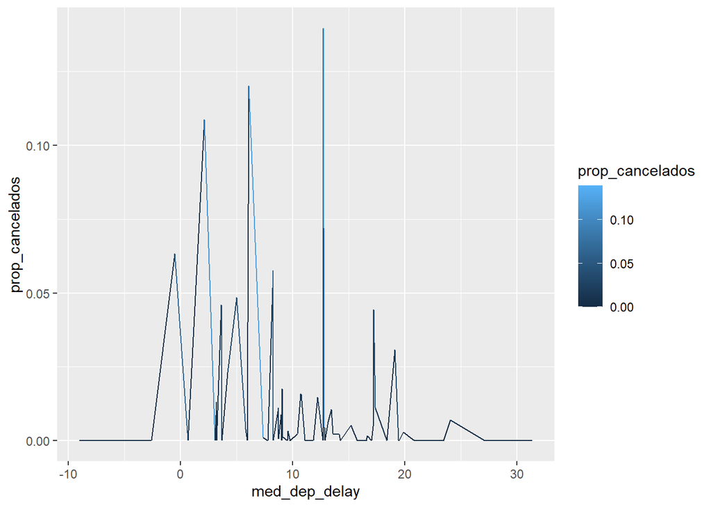

```r
ggplot(Prop_retraso_cancel_LGA) +
  geom_line(aes(x = med_dep_delay, y = prop_cancelados, col= prop_cancelados))
```

```r
EWR <- filter(vuelos, origin=="EWR")

Prop_retraso_cancel_EWR <- EWR %>%
  mutate(cancelados = (is.na(tailnum))) %>%
  group_by(origin, dest) %>%
  summarise(prop_cancelados = mean(cancelados),med_dep_delay = mean(dep_delay, na.rm = TRUE),med_arr_delay = mean(arr_delay, na.rm = TRUE)) %>% ungroup()
```

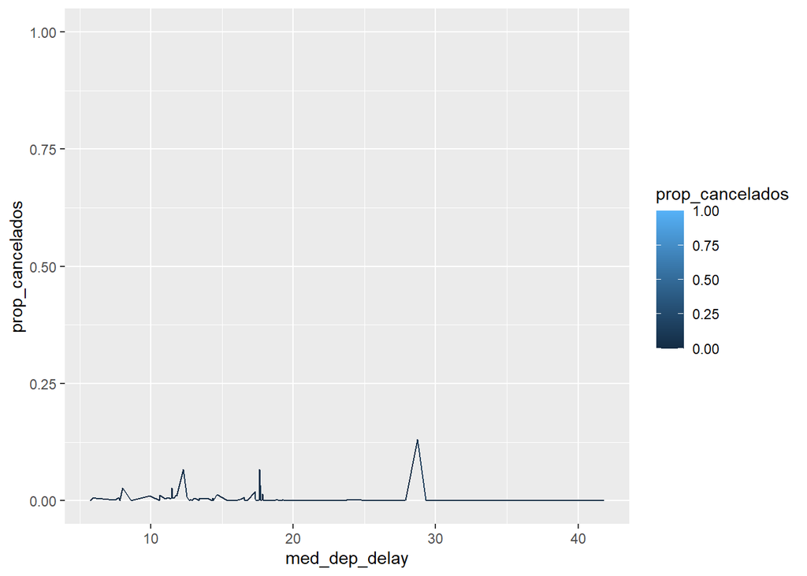

```r
ggplot(Prop_retraso_cancel_EWR) +
  geom_line(aes(x = med_dep_delay, y = prop_cancelados, col= prop_cancelados))
```

```r
JFK <- filter(vuelos, origin=="JFK")

Prop_retraso_cancel_JFK <- JFK %>%
  mutate(cancelados = (is.na(tailnum))) %>%
  group_by(origin, dest) %>%
  summarise(prop_cancelados = mean(cancelados),med_dep_delay = mean(dep_delay, na.rm = TRUE),med_arr_delay = mean(arr_delay, na.rm = TRUE)) %>% ungroup()
```

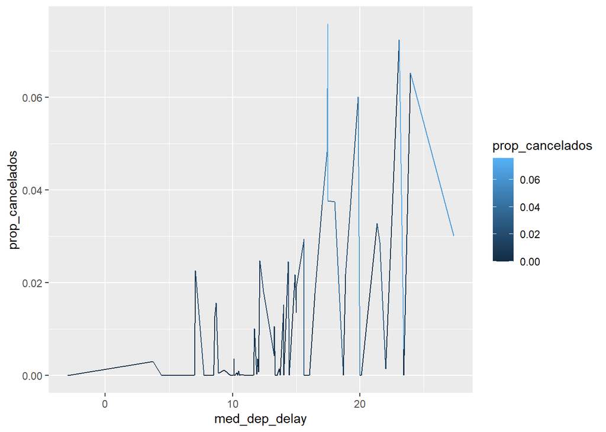

```r
ggplot(Prop_retraso_cancel_JFK) +
  geom_line(aes(x = med_dep_delay, y = prop_cancelados, col= prop_cancelados))
```

En el caso del aeropuerto JFK existe una relación entre el número de vuelos cancelados y el retraso en la salida de los vuelos. Sin embargo, en el caso del aeropuerto EWR podemos observar que no existe una relación entre las variables. Por último, el caso del aeropuerto LGA es algo más confuso puesto que no podemos determinar si existe o no una relación entre ambos parámetros.

#### 19. ¿Qué compañía aérea sufre los peores retrasos?

```r
vuelos %>%
   group_by(carrier) %>%
   summarise(dep_delay = mean(dep_delay, na.rm = TRUE)) %>%
   arrange(desc(dep_delay))
```

```
## # A tibble: 16 x 2
##    carrier dep_delay
##    <chr>       <dbl>
##  1 F9          20.2
##  2 EV          20.0
##  3 YV          19.0
##  4 FL          18.7
##  5 WN          17.7
##  6 9E          16.7
##  7 B6          13.0
##  8 VX          12.9
##  9 OO          12.6
## 10 UA          12.1
## 11 MQ          10.6
## 12 DL           9.26
## 13 AA           8.59
## 14 AS           5.80
## 15 HA           4.90
## 16 US           3.78
```

```r
vuelos %>%
   group_by(carrier) %>%
   summarise(arr_delay = mean(arr_delay, na.rm = TRUE)) %>%
   arrange(desc(arr_delay))
```

```
## # A tibble: 16 x 2
##    carrier arr_delay
##    <chr>       <dbl>
##  1 F9         21.9
##  2 FL         20.1
##  3 EV         15.8
##  4 YV         15.6
##  5 OO         11.9
##  6 MQ         10.8
##  7 WN          9.65
##  8 B6          9.46
##  9 9E          7.38
## 10 UA          3.56
## 11 US          2.13
## 12 VX          1.76
## 13 DL          1.64
## 14 AA          0.364
## 15 HA         -6.92
## 16 AS         -9.93
```

La compañia que sufre los peores retrasos es la F9.

#### 20. Queremos saber qué hora del día nos conviene volar si queremos evitar los retrasos en la salida.

```r
vuelos %>%
  group_by(hour) %>%
  summarise(dep_delay = mean(dep_delay, na.rm = TRUE)) %>%
  arrange(dep_delay)
```

```
## # A tibble: 20 x 2
##     hour dep_delay
##    <dbl>     <dbl>
##  1     5     0.688
##  2     6     1.64
##  3     7     1.91
##  4     8     4.13
##  5     9     4.58
##  6    10     6.50
##  7    11     7.19
##  8    12     8.61
##  9    13    11.4
## 10    14    13.8
## 11    23    14.0
## 12    15    16.9
## 13    16    18.8
## 14    22    18.8
## 15    17    21.1
## 16    18    21.1
## 17    21    24.2
## 18    20    24.3
## 19    19    24.8
## 20     1   NaN
```

La mejor hora para volar sería las 5 de la mañana.

#### 21. Queremos saber qué día de la semana nos conviene volar si queremos evitar los retrasos en la salida.

```r
library(lubridate)
make_dtime <- function(year, month, day, time) {
  make_datetime(year, month, day, time %/% 100, time %% 100)
}
vuelos_dt <- vuelos %>%
  filter(!is.na(dep_time), !is.na(arr_time)) %>%
  mutate(
    dep_time = make_dtime(year, month, day, dep_time),
    arr_time = make_dtime(year, month, day, arr_time),
    sched_dep_time = make_dtime(year, month, day, sched_dep_time),
    sched_arr_time = make_dtime(year, month, day, sched_arr_time)) %>%
  select(origin, dest, ends_with("delay"), ends_with("time"))
vuelos_dt %>%
  mutate(dow = wday(sched_dep_time)) %>%
  group_by(dow) %>%
  summarise(
    dep_delay = mean(dep_delay),
    arr_delay = mean(arr_delay, na.rm = TRUE)
  ) %>%
  print(n = Inf)
```

```
## # A tibble: 7 x 3
##     dow dep_delay arr_delay
##   <dbl>     <dbl>     <dbl>
## 1     1     11.5       4.82
## 2     2     14.7       9.65
## 3     3     10.6       5.39
## 4     4     11.7       7.05
## 5     5     16.1      11.7
## 6     6     14.7       9.07
## 7     7      7.62     -1.45
```

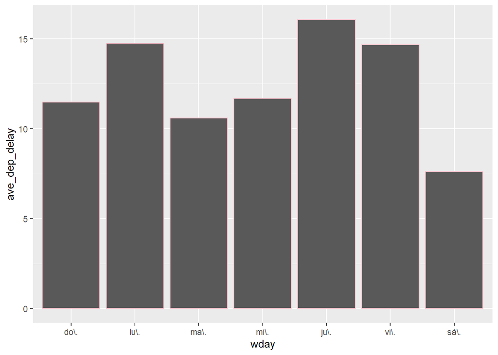

```r
vuelos_dt %>%
   mutate(wday = wday(dep_time, label = TRUE)) %>%
   group_by(wday) %>%
   summarize(ave_dep_delay = mean(dep_delay, na.rm = TRUE)) %>%
   ggplot(aes(x = wday, y = ave_dep_delay)) +
   geom_bar(stat = "identity", col = "pink")
```

El día más conveniente para viajar es el sábado como podemos ver en el gráfico de barras, ya que es el día en el que menos retrasos se producen.

#### 22. Para cada destino, calcula el total de minutos de retraso acumulado.

```r
retraso_totvuelos <- vuelos %>%
  filter(arr_delay > 0) %>%
  group_by(dest) %>%
  summarise(arr_delay = sum(arr_delay))
retraso_totvuelos
```

```
## # A tibble: 103 x 2
##    dest  arr_delay
##    <chr>     <dbl>
##  1 ABQ        4487
##  2 ACK        2974
##  3 ALB        9580
##  4 ANC          62
##  5 ATL      300299
##  6 AUS       39940
##  7 AVL        3671
##  8 BDL        6953
##  9 BGR        6940
## 10 BHM        7267
## # ... with 93 more rows
```

#### 23. Para cada uno de ellos, calcula la proporción del total de retraso para dicho destino.

```r
vuelos %>%
   filter(arr_delay > 0) %>%
   group_by(dest, origin, carrier, flight) %>%
   summarise(arr_delay = sum(arr_delay)) %>%
   group_by(dest) %>%
   mutate(
     arr_delay_prop = arr_delay / sum(arr_delay)
   ) %>%
   arrange(dest, desc(arr_delay_prop)) %>%
   select(carrier, flight, origin, dest, arr_delay_prop)
```

```
## # A tibble: 8,834 x 5
## # Groups:   dest [103]
##    carrier flight origin dest  arr_delay_prop
##    <chr>    <int> <chr>  <chr>          <dbl>
##  1 B6        1505 JFK    ABQ           0.567
##  2 B6          65 JFK    ABQ           0.433
##  3 B6        1191 JFK    ACK           0.475
##  4 B6        1491 JFK    ACK           0.414
##  5 B6        1291 JFK    ACK           0.0898
##  6 B6        1195 JFK    ACK           0.0208
##  7 EV        4309 EWR    ALB           0.174
##  8 EV        4271 EWR    ALB           0.137
##  9 EV        4117 EWR    ALB           0.0951
## 10 EV        4088 EWR    ALB           0.0865
## # ... with 8,824 more rows
```

#### 24. Es hora de aplicar todo lo que hemos aprendido para visualizar mejor los tiempos de salida para vuelos cancelados vs los no cancelados. Recuerda bien qué tipo de dato tenemos en cada caso. ¿Qué deduces acerca de los retrasos según la hora del día a la que está programada el vuelo de salida?

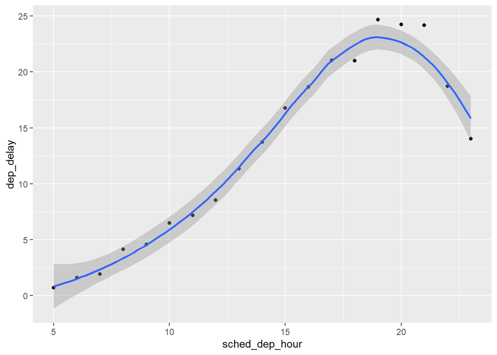

```r
vuelos_dt %>%
  mutate(sched_dep_hour = hour(sched_dep_time)) %>%
  group_by(sched_dep_hour) %>%
  summarise(dep_delay = mean(dep_delay)) %>%
  ggplot(aes(y = dep_delay, x = sched_dep_hour)) +
  geom_point() +
  geom_smooth()
```

Cómo podemos observar en el gráfico el retraso en la salida de los vuelos aumenta a medida que va pasando el día alcanzando su punto máximo aproximadamente entre las 6 y 8 de la tarde. Sin embargo, podemos apreciar como durante la madrugada los retrasos son menores.

#### 25. Subir la carpeta a github y facilitar la url.

El url de mi carpeta de github es: https://github.com/igarciamart/trabajo_personal.git